# Heatmap of TET2 mutation–associated hypermethylation signature

Published

July 22, 2025

This script generates a heatmap displaying DNA methylation profiles across a previously defined TET2 mutation–associated hypermethylation signature in the EVITA cohort, and sorted normal peripheral blood cell populations from healthy donors for comparison.

### Load required R packages

```r
.libPaths("/packages/")
if (!requireNamespace("pacman", quietly = TRUE)) install.packages("pacman")
pacman::p_load(
  matrixStats,
  tidyverse,
  data.table,
  fs,
  ComplexHeatmap,
  viridis,
  circlize,
  qs
)
```

### Project setup

```r
project_dir <- path("~/EVITA_EPIC_methylation_analysis")
r_data_dir <- path(project_dir, "r_data")
# Source color palettes
source(path(project_dir, "EPIC_array_analysis_color_palettes.R"))
```

### EVITA DNA methylation data

```r
fname <- "EVITA_DNA_methylation_EPIC_beta_values"
dt <- qread(path(r_data_dir, fname, ext = "qs"))
fname <- "EVITA_DNA_methylation_EPIC_sample_table"
sample_table <- readRDS(path(r_data_dir, fname, ext = "rds"))
# Check that the IDAT IDs match
stopifnot(identical(colnames(dt)[-1], sample_table[, IDAT]))
```

### EVITA somatic variant data processing

- Display the highest VAF for a patient with multiple mutations in the same gene.

```r
fname <- "EVITA_curated_variants_EPIC_analysis"
vaf <- readRDS(path(r_data_dir, fname, ext = "rds"))
vaf <- vaf[EPIC_Data == TRUE, .(Patient_ID_Timepoint, Hugo_Symbol, AF)]

# TET2 mutations
vaf_tet2 <- vaf[Hugo_Symbol == "TET2"]
vaf_tet2 <- vaf_tet2[order(Patient_ID_Timepoint, AF, decreasing = TRUE)]
vaf_tet2 <- vaf_tet2[!duplicated(Patient_ID_Timepoint)]
colnames(vaf_tet2)[-1] <- str_c("TET2_", colnames(vaf_tet2)[-1])

# IDH1/2 mutations
vaf_idh1 <- vaf[Hugo_Symbol == "IDH1"]
vaf_idh2 <- vaf[Hugo_Symbol == "IDH2"]
vaf_idhs <- rbind(vaf_idh1, vaf_idh2)
vaf_idhs[, Hugo_Symbol := "IDH"]
colnames(vaf_idhs)[-1] <- str_c("IDH_", colnames(vaf_idhs)[-1])

# DNMT3A mutations
vaf_dnmt3a <- vaf[Hugo_Symbol == "DNMT3A"]
vaf_dnmt3a <- vaf_dnmt3a[order(Patient_ID_Timepoint, AF, decreasing = TRUE)]
vaf_dnmt3a <- vaf_dnmt3a[!duplicated(Patient_ID_Timepoint)]
colnames(vaf_dnmt3a)[-1] <- str_c("DNMT3A_", colnames(vaf_dnmt3a)[-1])

# Merge
vaf <- merge(vaf_tet2, vaf_idhs, by = c("Patient_ID_Timepoint"), all = TRUE)
vaf <- merge(vaf, vaf_dnmt3a, by = c("Patient_ID_Timepoint"), all = TRUE)

sample_table <- merge(sample_table, vaf, by = "Patient_ID_Timepoint",
                      sort = FALSE, all.x = TRUE)
```

### Sorted blood cells

- EPICv1 array data from:
  - https://www.ncbi.nlm.nih.gov/geo/query/acc.cgi?acc=GSE167998
- Excluded artificially mixed samples (MIX)

```r
fname <- "GSE167998_flow_sorted_blood_EPIC_beta_values"
dt_blood <- readRDS(path(r_data_dir, fname, ext = "rds"))
fname <- "GSE167998_flow_sorted_blood_EPIC_sample_table"
sample_table_blood <- readRDS(path(r_data_dir, fname, ext = "rds"))
# Check that the sample IDs match between the data and sample table
stopifnot(identical(colnames(dt_blood)[-1], sample_table_blood[, Sample_ID]))
sample_table_blood <- sample_table_blood[CellType != "MIX"]

# Number of samples per cell type
sample_table_blood[, .N, CellType]
```

```
    CellType     N
      <char> <int>
 1:    CD4nv     5
 2:   CD4mem     4
 3:      Bas     6
 4:     Bmem     6
 5:      Bnv     4
 6:     Treg     3
 7:   CD8mem     4
 8:    CD8nv     5
 9:      Eos     4
10:       NK     4
11:      Neu     6
12:     Mono     5
```

```r
sample_ids <- sample_table_blood[, Sample_ID]
dt_blood <- dt_blood[, .SD, .SDcols = c("ProbeID", sample_ids)]
stopifnot(identical(colnames(dt_blood)[-1], sample_table_blood[, Sample_ID]))
```

### HSC and progenitor cells

- HM450 array data from:
  - https://www.ncbi.nlm.nih.gov/geo/query/acc.cgi?acc=GSE63409
- Excluded AML LSCs and Blasts
- Excluded low quality samples

```r
fname <- "GSE63409_hematopoietic_stem_progenitor_HM450_beta_values"
dt_hsc <- readRDS(path(r_data_dir, fname, ext = "rds"))
fname <- "GSE63409_hematopoietic_stem_progenitor_HM450_sample_table"
sample_table_hsc <- readRDS(path(r_data_dir, fname, ext = "rds"))
# Check that the sample IDs match between the data and sample table
stopifnot(identical(colnames(dt_hsc)[-1], sample_table_hsc[, name]))
sample_table_hsc <- sample_table_hsc[!cell_type %in% c("BLAST", "LSC")]
sample_table_hsc <- sample_table_hsc[frac_dt_cg > 0.8]

# Number of samples per cell type
sample_table_hsc[, .N, cell_type]
```

```
   cell_type     N
      <char> <int>
1:       HSC     5
2:       MPP     4
3:      LMPP     5
4:       CMP     5
5:       GMP     5
6:       MEP     5
```

```r
names <- sample_table_hsc[, name]
dt_hsc <- dt_hsc[, .SD, .SDcols = c("ProbeID", names)]
stopifnot(identical(colnames(dt_hsc)[-1], sample_table_hsc[, name]))
probe_ids <- dt_hsc[, ProbeID]
length(probe_ids)
```

```
[1] 486427
```

### Probe annotations

- EPICv1 probe manifest:
  - https://zhouserver.research.chop.edu/InfiniumAnnotation
- ENCODE Candidate Cis-Regulatory Elements (cCRE) annotations:
  - https://screen.encodeproject.org/index/cversions
  - Registry V2 (Version used in above-cited Nature paper)
- TET2 mutation-associated hypermethylation signature
  - https://pubmed.ncbi.nlm.nih.gov/34663818
  - Previously defined as significantly hypermethylated in granulocyte from CCUS patients with TET2 mutations
  - 12,096 CpGs with p < 7.7e-6 as provided in Supplementary Data 3

```r
fname <- "EPICv1_manifest_hg38"
dt_probes <- readRDS(path(r_data_dir, fname, ext = "rds"))
fname <- "EVITA_DNA_methylation_EPIC_probe_metadata"
probe_meta <- readRDS(path(r_data_dir, fname, ext = "rds"))

# Subset probes from manifest
dt_probes <- dt_probes[ProbeID %in% probe_ids]

# CpG islands annotation
dt_probes[, cgi := CGIposition %in% "Island"]

# ENCODE PLS annotation
probe_ids <- probe_meta[cCRE_ENCODE %like% "PLS", ProbeID]
dt_probes[, encode_pls := ProbeID %in% probe_ids]

# ENCODE dELS annotation
probe_ids <- probe_meta[cCRE_ENCODE %like% "dELS", ProbeID]
dt_probes[, encode_dels := ProbeID %in% probe_ids]

# TET2 CCUS differential methylation
probe_ids <- probe_meta[tet2mut_signature == TRUE, ProbeID]
dt_probes[, tet2mut_signature := ProbeID %in% probe_ids]
```

### Probe filtering

- Exclude problematic probes and non-CpG probes, and probes on the sex chromosomes and mitochondrial DNA

```r
dt_probes <- dt_probes[MASK_general == FALSE]
dt_probes <- dt_probes[probeType == "cg"]
dt_probes <- dt_probes[!(seqnames %in% c("chrX", "chrY", "chrM"))]
probe_ids <- dt_probes[, ProbeID]
dt <- dt[ProbeID %in% probe_ids]
```

- Select TET2mut methylation signature probes

```r
probe_ids <- probe_meta[tet2mut_signature == TRUE, ProbeID]
dt <- dt[ProbeID %in% probe_ids]
```

- Exclude probes with >20% missing data across all samples

```r
probe_ids <- probe_meta[percent_missing_vals < 20, ProbeID]
dt <- dt[ProbeID %in% probe_ids]
```

#### Sample ordering

- Order samples by median DNA methylation across TET2mut hypermethylation signature probes

```r
sample_table <- sample_table[order(-median_tet2_sig)]
idats_ordered <- sample_table[, IDAT]
dt <- dt[, .SD, .SDcols = c("ProbeID", idats_ordered)]
```

### Heatmap data preparation

```r
df <- as.matrix(dt, rownames = "ProbeID")
dim(df)
```

```
[1] 3821  178
```

```r
stopifnot(identical(colnames(df), sample_table[, IDAT]))
```

### Heatmap sample annotations

```r
column_ha <- HeatmapAnnotation(
  Sex = sample_table[, Sex],
  Age = sample_table[, Age_inclusion_years],
  Diagnosis = sample_table[, Diagnosis],
  Treatment = sample_table[, Treatment_arm],
  "DNMT3A VAF" = sample_table[, DNMT3A_AF],
  "IDH VAF" = sample_table[, IDH_AF],
  "TET2 VAF" = sample_table[, TET2_AF],
  col = list(
    Sex = sex_colors,
    Age = col_fun_age,
    Diagnosis = diagnosis_colors,
    Treatment = treatment_arm_colors,
    "DNMT3A VAF" = col_fun_turbo100,
    "IDH VAF" = col_fun_turbo100,
    "TET2 VAF" = col_fun_turbo100
  ),
  show_legend = FALSE,
  show_annotation_name = TRUE,
  gp = gpar(col = "black", lwd = 0),
  simple_anno_size = unit(0.4, "cm")
)
stopifnot(identical(sample_table[, IDAT], colnames(df)))
patient_ids <- unique(sample_table[, PatientID])
patient_ids <- factor(sample_table[, PatientID], levels = patient_ids)
```

### Heatmap probe annotations

```r
probe_ids <- rownames(df)
dt_probes <- dt_probes[ProbeID %in% probe_ids]
stopifnot(identical(dt_probes[, ProbeID], rownames(df)))
row_ha <- rowAnnotation(
  "CpG Island" = dt_probes[, cgi],
  Promoter = dt_probes[, encode_pls],
  Enhancer = dt_probes[, encode_dels],
  col = list(
    "CpG Island" = binary_colors,
    Promoter = binary_colors,
    Enhancer = binary_colors
  ),
  show_legend = FALSE,
  show_annotation_name = TRUE,
  annotation_name_side = "top"
)
```

### Heatmap

```r
stopifnot(identical(colnames(df), sample_table[, IDAT]))
ht <- Heatmap(df,
  cluster_columns = FALSE,
  show_column_dend = FALSE,
  show_column_names = FALSE,
  cluster_rows = TRUE,
  show_row_dend = FALSE,
  show_row_names = FALSE,
  col = col_fun_turbo100,
  top_annotation = column_ha,
  left_annotation = row_ha,
  show_heatmap_legend = TRUE,
  heatmap_legend_param = list(title = "DNA methylation\nβ value"),
  use_raster = FALSE,
  border = FALSE,
  border_gp = gpar(lwd = 1)
)
```

- Draw heatmap and save the probe order

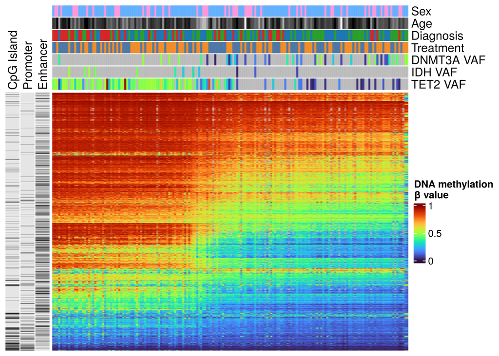

```r
ht_drawn <- draw(ht, background = "transparent")
```

```r
probe_order <- row_order(ht_drawn)
probe_ids_ordered <- rownames(df)[probe_order]
```

- Draw heatmap sample color legends

```r
column_legends <- packLegend(
  Legend(
    title = "Sex",
    at = names(sex_colors),
    legend_gp = gpar(fill = sex_colors)
  ),
  Legend(
    title = "Age",
    col_fun = col_fun_age,
    title_gp = gpar(fontsize = 10),
    direction = "horizontal"
  ),
  Legend(
    title = "Diagnosis",
    at = names(diagnosis_colors),
    legend_gp = gpar(fill = diagnosis_colors)
  ),
  Legend(
    title = "Treatment Arm",
    at = names(treatment_arm_colors),
    legend_gp = gpar(fill = treatment_arm_colors)
  ),
  Legend(
    title = "VAF",
    col_fun = col_fun_turbo100,
    title_gp = gpar(fontsize = 10),
    direction = "horizontal"
  )
)
```

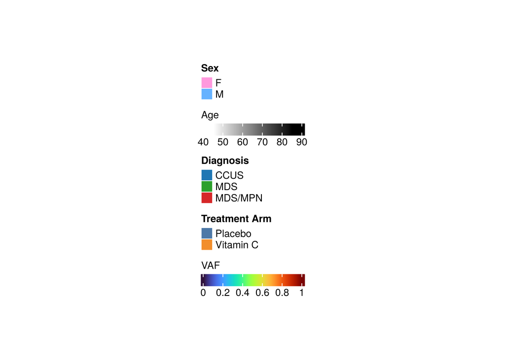

```r
draw(column_legends)
```

### HSC and progenitor cells heatmap

```r
dt_hsc <- dt_hsc[ProbeID %in% probe_ids_ordered]
dt_hsc <- dt_hsc[match(probe_ids_ordered, ProbeID)]
stopifnot(identical(dt_hsc[, ProbeID], probe_ids_ordered))
stopifnot(identical(colnames(dt_hsc)[-1], sample_table_hsc[, name]))

# Order of cell types
cell_types <- c("HSC", "MPP", "LMPP", "CMP", "GMP", "MEP")
dt_hsc_order <- data.table(
  cell_types,
  cell_type_order = 1:length(cell_types)
)

sample_table_hsc <- merge(
  sample_table_hsc,
  dt_hsc_order,
  by.x = "cell_type",
  by.y = "cell_types",
  all.x = TRUE
)

sample_table_hsc <- sample_table_hsc[
  order(cell_type_order)
]
sample_table_hsc[, cell_type := factor(cell_type, levels = cell_types)]
sample_ids <- sample_table_hsc[, name]
dt_hsc <- dt_hsc[, .SD, .SDcols = c("ProbeID", sample_ids)]
df_hsc <- as.matrix(dt_hsc, rownames = "ProbeID")
stopifnot(identical(colnames(df_hsc), sample_table_hsc[, name]))

# Heatmap sample annotations
column_ha_hsc <- HeatmapAnnotation(
  Cell_Type = sample_table_hsc[, cell_type],
  col = list(
    Cell_Type = progenitor_colors
  ),
  show_legend = TRUE,
  show_annotation_name = FALSE,
  gp = gpar(col = "white", lwd = 0.1),
  simple_anno_size = unit(0.6, "cm")
)

# Heatmap
ht_hsc <- Heatmap(df_hsc,
  cluster_columns = FALSE,
  show_column_dend = FALSE,
  show_column_names = FALSE,
  column_split = sample_table_hsc[, cell_type],
  column_gap = unit(0, "cm"),
  cluster_column_slices = TRUE,
  column_title = NULL,
  top_annotation = column_ha_hsc,
  cluster_rows = FALSE,
  show_row_dend = FALSE,
  show_row_names = FALSE,
  col = col_fun_turbo100,
  show_heatmap_legend = FALSE,
  use_raster = FALSE,
  border = FALSE,
  border_gp = gpar(lwd = 0)
)
```

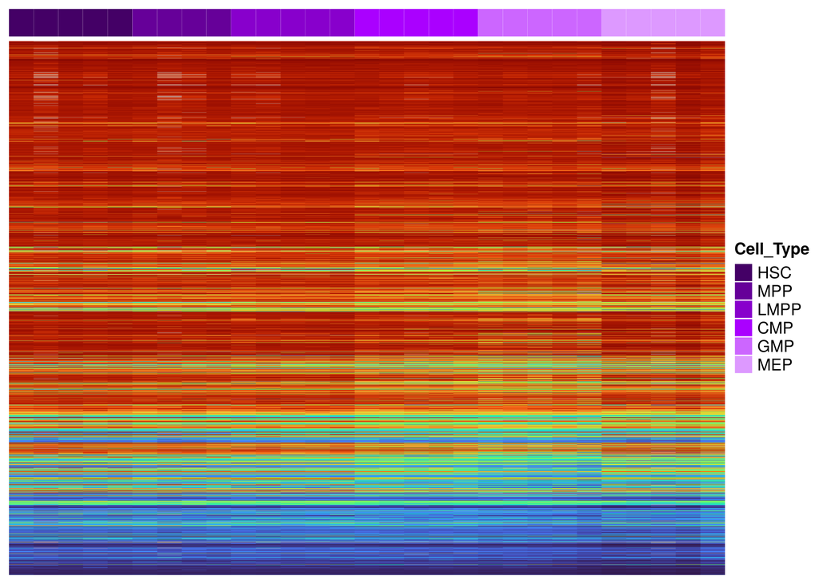

```r
ht_drawn <- draw(ht_hsc, background = "transparent")
```

### Sorted blood cells heatmap

```r
dt_blood <- dt_blood[ProbeID %in% probe_ids_ordered]
dt_blood <- dt_blood[match(probe_ids_ordered, ProbeID)]
stopifnot(identical(dt_blood[, ProbeID], probe_ids_ordered))
stopifnot(identical(colnames(dt_blood)[-1], sample_table_blood[, Sample_ID]))

# Order of cell types
cell_types <- c("CD4nv", "CD8nv", "Bnv",
                "NK", "CD4mem", "Treg", "CD8mem", "Bmem",
                "Bas", "Mono", "Eos", "Neu")
dt_blood_order <- data.table(
  cell_types,
  cell_type_order = 1:length(cell_types)
)
sample_table_blood <- merge(
  sample_table_blood,
  dt_blood_order,
  by.x = "CellType",
  by.y = "cell_types",
  all.x = TRUE
)
sample_table_blood <- sample_table_blood[order(cell_type_order)]
sample_table_blood[, CellType := factor(CellType, levels = cell_types)]
sample_ids <- sample_table_blood[, Sample_ID]
dt_blood <- dt_blood[, .SD, .SDcols = c("ProbeID", sample_ids)]
df_blood <- as.matrix(dt_blood, rownames = "ProbeID")
stopifnot(identical(colnames(df_blood), sample_table_blood[, Sample_ID]))

# Heatmap sample annotations
column_ha_blood <- HeatmapAnnotation(
  Cell_Type = sample_table_blood[, CellType],
  col = list(
    Cell_Type = sorted_blood_colors
  ),
  show_legend = TRUE,
  show_annotation_name = FALSE,
  gp = gpar(col = "white", lwd = 0.1),
  simple_anno_size = unit(0.6, "cm")
)

# Heatmap
ht_blood <- Heatmap(df_blood,
  cluster_columns = FALSE,
  show_column_dend = FALSE,
  show_column_names = FALSE,
  column_split = sample_table_blood[, CellType],
  column_gap = unit(
    c(
      0, 0, 0.5,  # CD4nv to NK
      0, 0, 0, 0, 0.5,  # NK to Bas
      0, 0, 0  # Bas to Neu
    ),
    "cm"
  ),
  cluster_column_slices = TRUE,
  column_title = NULL,
  top_annotation = column_ha_blood,
  cluster_rows = FALSE,
  show_row_dend = FALSE,
  show_row_names = FALSE,
  col = col_fun_turbo100,
  show_heatmap_legend = FALSE,
  use_raster = FALSE,
  border = FALSE,
  border_gp = gpar(lwd = 1)
)
```

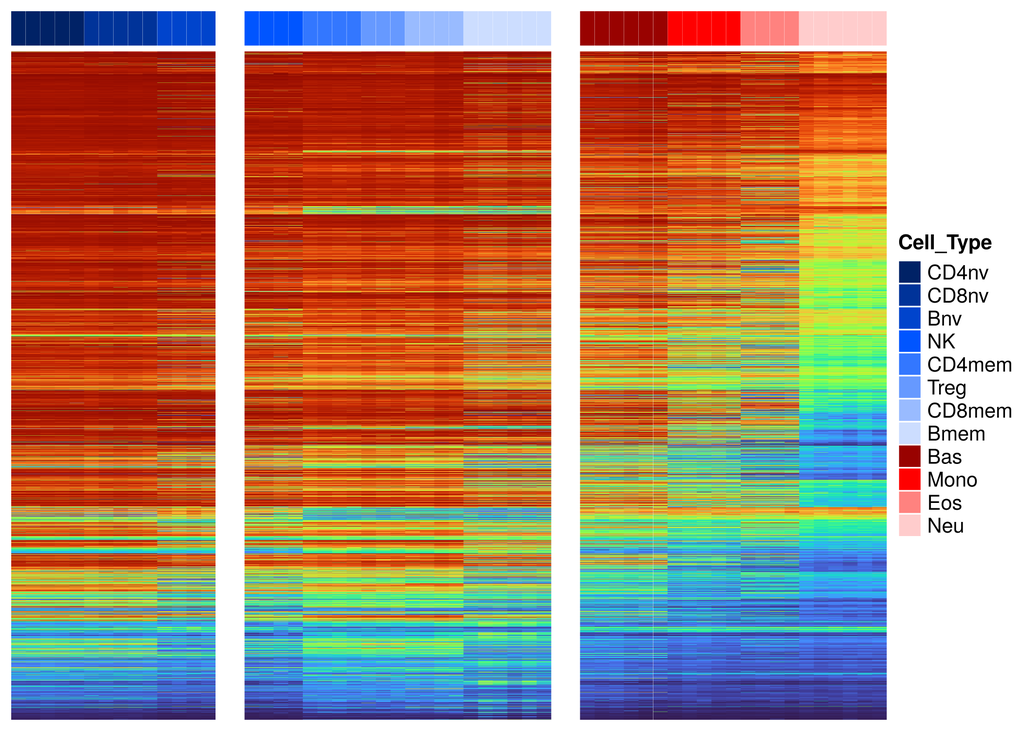

```r
ht_drawn <- draw(ht_blood, background = "transparent")
```